# Pilot Practices

Janette Avelar

2024-07-11

```r
#manual branding - file won't load
transcend_cols = c("#1A4C81","#59C3B4","#EF464B","#ADE0EE")
transcend_cols2 = c("#BC2582","#FFA630","#FFDE42","#99C24D","#218380","#D3B7D7")
transcend_grays = c("#4D4D4F","#9D9FA2","#D1D3D4")
transcend_na = transcend_grays[2]
theme_transcend = theme_gdocs(base_size = 14, base_family = "Open Sans") +
  theme(
    plot.title = element_text(family = "Bebas Neue", color = "black"),
    plot.background = element_blank(),
    axis.text = element_text(colour = "black"),
    axis.title = element_text(colour = "black"),
    panel.border = element_rect(colour = "#4D4D4F"),
    strip.text = element_text(size = rel(0.8)),
    plot.margin = margin(10, 24, 10, 10, "pt")
  )
theme_set(theme_transcend)
```

**What do schools most want to pilot in the next 5 years?**

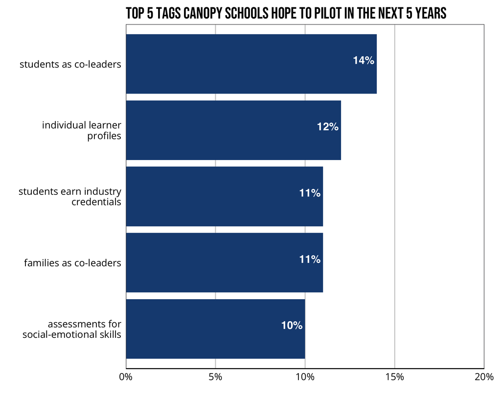

```r
tags %>%
  select(school_id, starts_with("pilot")) %>%
  pivot_longer(cols = starts_with("pilot"),
               names_to = "variable",
               values_to = "usage") %>%
  group_by(variable) %>%
  summarize(n = sum(usage),
            pct = round(n/189, 2)) %>%
  mutate(variable = str_replace_all(variable, "pilot", "practices")) %>%
  left_join(labels, by = "variable") %>%
  arrange(-n) %>%
  slice_head(n = 5) %>%
  ggplot(., aes(pct, reorder(label, pct))) +
  geom_col(fill = transcend_cols[1]) +
  scale_x_continuous(expand = c(0, 0), limits = c(0, .2), labels = scales::percent_format()) +
  scale_y_discrete(labels = wrap_format(25)) +
  geom_text(aes(label = scales::label_percent(accuracy = 1)(pct)),
            hjust = 1.1,
            vjust = 0,
            color = "white",
            fontface = "bold",
            size = 5.5,
            family = "sans") +
  theme(panel.grid.major.y = element_blank()) +
  labs(x = "",
       y = "",
       title = str_wrap("Top 5 tags Canopy schools hope to pilot in the next 5 years", 60))
```

**Are there broad patterns in the practices schools hope to implement in the next five years?**

The graph below was created by adding the number of tags a school selected within a cluster, and dividing it by the number of tags present in the cluster for 2024. The y-axis displays that percentage, on average. Postsecondary pathways was the cluster from which most schools selected practices they’re interested in piloting. The “none,” or miscellaneous, cluster was quite high, which may indicate we should look closer at it to tease out more differences among those 24 tags. Practices related to individualized learning were selected much less frequently.

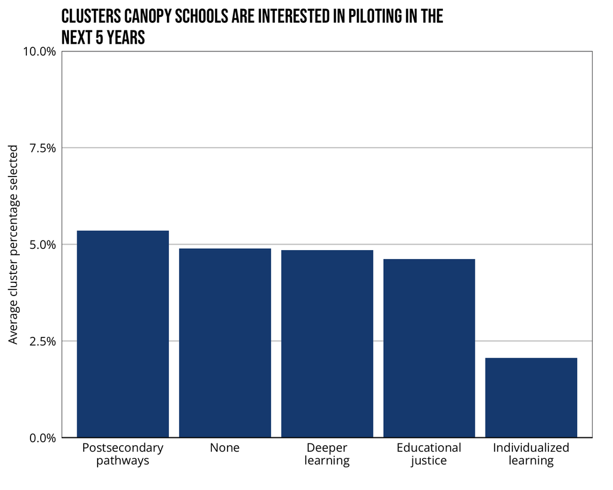

```r
#read in cluster information
cluster <- import(here("data/longitudinal", "tag_clusters_longitudinal.csv")) %>%
  janitor::clean_names() %>%
  select(tag, cluster = proposed_cluster_for_preliminary_24_analysis) %>%
  mutate(cluster = case_when(
    cluster == "Postsecondary" ~ "Postsecondary pathways",
    cluster == "Ed justice" ~ "Educational justice",
    cluster == "Individualized" ~ "Individualized learning",
    cluster == "None?" ~ "None",
    TRUE ~ as.character(cluster)
  ))
#link to pilot tags
pilot_clusters <- tags %>%
  select(school_id, starts_with("pilot")) %>%
  pivot_longer(cols = starts_with("pilot"),
               names_to = "variable",
               values_to = "usage") %>%
  mutate(variable = str_replace_all(variable, "pilot", "practices")) %>%
  left_join(labels, by = "variable") %>%
  select(school_id, tag = label, usage) %>%
  left_join(cluster, by = "tag")
#cluster totals
tots <- pilot_clusters %>%
  select(tag, cluster) %>%
  unique() %>%
  mutate(rate = 1) %>%
  group_by(cluster) %>%
  summarize(total = sum(rate))
#weighted total for each school
pilot_clusters %>%
  group_by(school_id, cluster) %>%
  summarize(n = sum(usage)) %>%
  ungroup() %>%
  left_join(tots, by = "cluster") %>%
  mutate(pct = n/total) %>%
  group_by(cluster) %>%
  summarize(wt_sum = sum(pct),
            wt_mean = mean(pct),
            mean = mean(n),
            median = median(n)) %>%
  ggplot(., aes(reorder(cluster, -wt_mean), wt_mean)) +
  geom_col(fill = transcend_cols[1]) +
  scale_y_continuous(expand = c(0, 0), limits = c(0, .1), labels = scales::percent_format()) +
  scale_x_discrete(labels = wrap_format(15)) +
  theme(panel.grid.major.x = element_blank()) +
  labs(y = "Average cluster percentage selected",
       x = "",
       title = str_wrap("Clusters Canopy schools are interested in piloting in the next 5 years", 60))
```

I think the graph above gives us some interesting information, but it’s a little hard to understand, in part because the numbers turn out so small. When I transform them to make them more meaningful, it comes out to schools selecting less than 1 tag in each cluster (except for the ‘none’ category). I think this is because schools that did not select those tags are included in the calculation, leaving a lot of 0’s that pull the numbers down. Trying to figure this out as a next step in the figure below. Here, I excluded all 0 values before calculating and mapped the mean number of tags selected, rather than the percentage. Notice that ‘none’ comes out as the top cluster, and postsecondary pathways is no longer the top cluster, but rather, educational justice is. Not totally sure what to make of this, beyond again indicating the need to describe that misc. cluster better.

*Update* After experimenting, I’m realizing the 0’s might not be the issue, but rather, that schools were only able to select up to 5 tags even though there are more tags in each cluster, thus that percentage will never be very high. Any suggestions on how to handle this? It doesn’t feel very meaningful to say that schools on average selected 1-1.6 tags in each cluster, but maybe it’s just that we don’t see very big differences in the type of tags selected when using our established clusters.

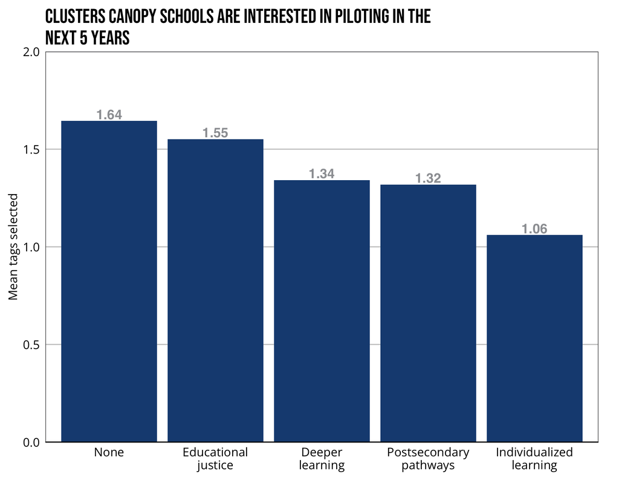

```r
pilot_clusters %>%
  filter(usage == 1) %>%
  group_by(school_id, cluster) %>%
  summarize(n = sum(usage)) %>%
  ungroup() %>%
  left_join(tots, by = "cluster") %>%
  mutate(pct = n/total) %>%
  group_by(cluster) %>%
  summarize(wt_sum = sum(pct),
            wt_mean = mean(pct),
            mean = mean(n),
            median = median(n)) %>%
  ggplot(., aes(reorder(cluster, -mean), mean)) +
  geom_col(fill = transcend_cols[1]) +
  scale_y_continuous(expand = c(0, 0), limits = c(0, 2)) +
  scale_x_discrete(labels = wrap_format(15)) +
  geom_text(aes(label = round(mean, 2)),
            vjust = -.2,
            color = transcend_na,
            fontface = "bold",
            size = 5.5,
            family = "sans") +
  theme(panel.grid.major.x = element_blank()) +
  labs(y = "Mean tags selected",
       x = "",
       title = str_wrap("Clusters Canopy schools are interested in piloting in the next 5 years", 60))
```

Modifying the graph to include the number of tags in each cluster schools already use:

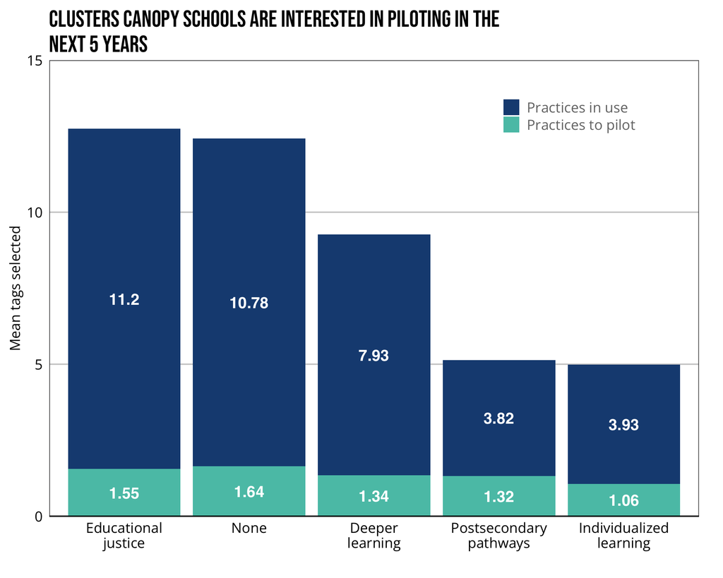

```r
tags <- full %>%
  select(school_id, starts_with("practices")) %>%
  pivot_longer(cols = starts_with("practices"),
               names_to = "variable",
               values_to = "usage") %>%
  left_join(labels, by = "variable") %>%
  rename("tag" = label) %>%
  left_join(cluster, by = "tag") %>%
  group_by(school_id, cluster) %>%
  summarize(n = sum(usage)) %>%
  group_by(cluster) %>%
  summarize(mean = mean(n)) %>%
  mutate(type = "Practices in use")
pilot_clusters %>%
  filter(usage == 1) %>%
  group_by(school_id, cluster) %>%
  summarize(n = sum(usage)) %>%
  group_by(cluster) %>%
  summarize(mean = mean(n)) %>%
  mutate(type = "Practices to pilot") %>%
  bind_rows(tags) %>%
  ggplot(., aes(reorder(cluster, -mean), mean, fill = type)) +
  geom_bar(stat = "identity") +
  scale_fill_manual(values = transcend_cols) +
  scale_y_continuous(expand = c(0, 0), limits = c(0, 15)) +
  scale_x_discrete(labels = wrap_format(15)) +
  geom_text(aes(label = round(mean, 2)),
            position = position_stack(vjust = .5),
            color = "white",
            fontface = "bold",
            size = 5.5,
            family = "sans") +
  theme(panel.grid.major.x = element_blank(),
        legend.position = c(.8,.9)) +
  labs(y = "Mean tags selected",
       x = "",
       title = str_wrap("Clusters Canopy schools are interested in piloting in the next 5 years", 60),
       fill = "")
```

Alternate version, using `facet` instead of stacking the bars:

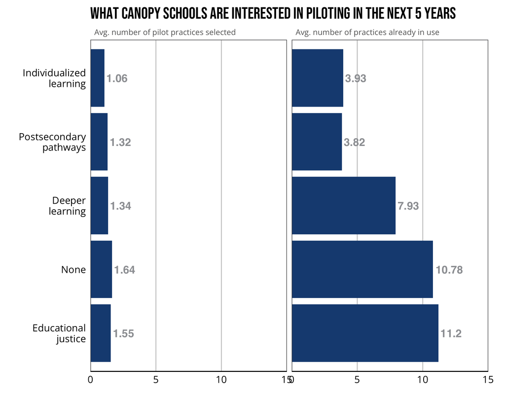

```r
pilot_clusters %>%
  filter(usage == 1) %>%
  group_by(school_id, cluster) %>%
  summarize(n = sum(usage)) %>%
  group_by(cluster) %>%
  summarize(mean = mean(n)) %>%
  mutate(type = "Avg. number of pilot practices selected") %>%
  bind_rows(tags) %>%
  mutate(type = ifelse(type == "Practices in use", "Avg. number of practices already in use", as.character(type))) %>%
  ggplot(., aes(mean, reorder(cluster, -mean))) +
  geom_bar(stat = "identity", fill = transcend_cols[1]) +
  scale_x_continuous(expand = c(0, 0), limits = c(0, 15)) +
  scale_y_discrete(labels = wrap_format(15)) +
  geom_text(aes(label = round(mean, 2)),
            vjust = .5,
            hjust = -0.1,
            color = transcend_na,
            fontface = "bold",
            size = 5.5,
            family = "sans") +
  theme(panel.grid.major.y = element_blank()) +
  labs(x = "",
       y = "",
       title = str_wrap("What Canopy schools are interested in piloting in the next 5 years", 66),
       fill = "") +
  facet_wrap(~type)
```

Exploring the graph above once more, using number of schools as the denominator rather than number of tags:

More than half of Canopy schools are interested in piloting 1 or more practices related to Educational Justice, and nearly half want to pilot a practice related to Deeper Learning. Again, we see that the “None” category is the highest rated, likely if not entirely due to the size of the cluster.

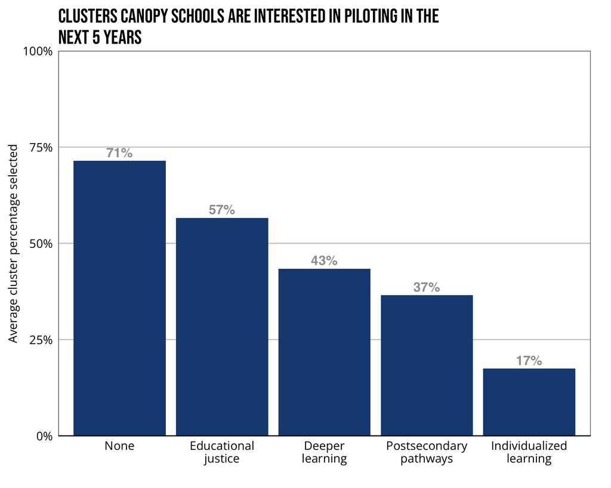

```r
pilot_clusters %>%
  group_by(school_id, cluster) %>%
  summarize(n = sum(usage)) %>%
  mutate(selection = ifelse(n > 0, 1, 0)) %>%
  group_by(cluster) %>%
  summarize(pct = sum(selection)/189) %>%
  ggplot(., aes(reorder(cluster, -pct), pct)) +
  geom_col(fill = transcend_cols[1]) +
  scale_y_continuous(expand = c(0, 0), limits = c(0, 1), labels = scales::percent_format()) +
  scale_x_discrete(labels = wrap_format(15)) +
  theme(panel.grid.major.x = element_blank()) +
  geom_text(aes(label = scales::label_percent(accuracy = 1)(pct)),
            nudge_y = 0.01,
            vjust = 0,
            color = transcend_na,
            fontface = "bold",
            size = 5.5,
            family = "sans") +
  labs(y = "Average cluster percentage selected",
       x = "",
       title = str_wrap("Clusters Canopy schools are interested in piloting in the next 5 years", 60))
```

**When we’re dividing pilot tags into clusters, which tags are selected the most?**

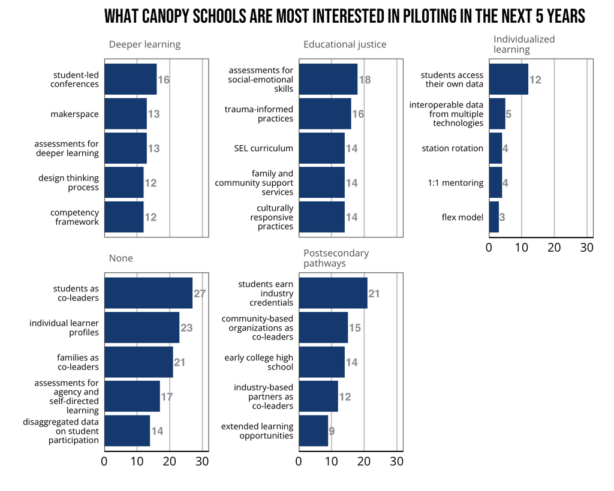

```r
pilot_clusters %>%
  group_by(cluster, tag) %>%
  summarize(n = sum(usage, na.rm = TRUE)) %>%
  ungroup() %>%
  group_by(cluster) %>%
  arrange(-n) %>%
  slice_head(n = 5) %>%
  ggplot(., aes(n, reorder(tag, n))) +
  geom_col(fill = transcend_cols[1]) +
  scale_x_continuous(expand = c(0, 0), limits = c(0, 32)) +
  scale_y_discrete(labels = wrap_format(20)) +
  theme(panel.grid.major.y = element_blank(),
        axis.text.y = element_text(size = 10)) +
  geom_text(aes(label = n),
            vjust = .5,
            hjust = -0.1,
            color = transcend_na,
            fontface = "bold",
            size = 4.5,
            family = "sans") +
  facet_wrap(~cluster, scales = "free_y", labeller = label_wrap_gen(width = 20)) +
  labs(y = "",
       x = "",
       title = str_wrap("What Canopy schools are most interested in piloting in the next 5 years", 75))
```

**To what extent do school characteristics play a role in the tags they want to pilot?**

Quick defs:  
-Binary high/low = High if more than half the tags in that cluster are in use  
-Tri high/average/low = High if mean+SD; low if mean-SD, average within 1 SD

```r
#create cluster score
cluster_score <- full %>%
  select(school_id, starts_with("practices")) %>%
  pivot_longer(cols = starts_with("practices"),
                 names_to = "variable",
                 values_to = "usage") %>%
  left_join(labels, by = "variable") %>%
  rename("tag" = label) %>%
  left_join(cluster, by = "tag") %>%
  group_by(school_id, cluster) %>%
  summarize(n = sum(usage)) %>%
  left_join(tots, by = "cluster") %>%
  mutate(pct = n/total,
         mean = mean(pct),
         sd = sd(pct),
         engagement_bi = case_when(
           pct >= 0.5 ~ "High",
           TRUE ~ "Low"
         ),
         engagement_tri = case_when(
           pct > mean + sd ~ "High",
           pct < mean - sd ~ "Low",
           TRUE ~ "Average"
         )) %>%
  #add outcome
  left_join(pilot_clusters, by = c("school_id", "cluster")) %>%
  group_by(school_id, cluster) %>%
  mutate(pilot_score = sum(usage),
         pilot_score = ifelse(pilot_score >= 1, 1, 0)) %>%
  select(-c(usage,tag)) %>%
  unique()
#prep base data
mod_dat <- full %>%
    select(school_id, school_locale, school_type, grades_pk, grades_elementary, grades_middle, grades_high, school_enrollment, pct_bipoc, pct_ell, pct_frpl, pct_swd, leadership_diversity) %>%
    mutate(leadership_diversity = gsub("people", "leaders", leadership_diversity),
           school_locale = factor(school_locale, levels = c("Urban", "Suburban", "Rural", "Multiple")),
           school_type = factor(school_type, levels = c("Public district school", "Public charter school", "Independent (private) school")),
           leadership_diversity = factor(leadership_diversity, levels = c("0 - 24% leaders of color", "25 - 49% leaders of color", "50 - 74% leaders of color", "75 - 100% leaders of color")),
           school_enrollment = as.numeric(scale(school_enrollment, center = TRUE, scale = TRUE))) %>%
    mutate(across(starts_with("pct"), ~as.numeric(scale(., center = TRUE, scale = TRUE)))) %>%
  drop_na()

# model function
log_model <- function(outcome, data, title){ #outcome needs to be dummy
  #model
  mod <- glm(as.formula(paste(outcome, "~ school_locale + school_type + grades_pk + grades_elementary + grades_middle + grades_high + school_enrollment + pct_bipoc + pct_ell + pct_frpl + pct_swd + leadership_diversity + engagement_tri")),
             family = "binomial",
             data = data)
  # set labels
  cov_labels <- c(
    "school_typeIndependent (private) school" = "Independent (private) school",
    "school_typePublic charter school" = "Public charter school",
    "grades_pk" = "PreK",
    "grades_elementary" = "Elementary",
    "grades_middle" = "Middle",
    "grades_high" = "High",
    "school_enrollment" = "School Enrollment",
    "pct_bipoc" = "% BIPOC students",
    "pct_ell" = "% EL-designated students",
    "pct_frpl" = "% FRPL-eligible",
    "pct_swd" = "% Students with disabilities",
    "school_localeMultiple" = "Multiple locales",
    "school_localeSuburban" = "Suburban",
    "school_localeRural" = "Rural",
    "leadership_diversity25 - 49% leaders of color" = "25-49% leaders of color",
    "leadership_diversity50 - 74% leaders of color" = "50-74% leaders of color",
    "leadership_diversity75 - 100% leaders of color" = "75-100% leaders of color",
    "engagement_triHigh" = "High engagement with cluster",
    "engagement_triAverage" = "Average engagement with cluster",
    "engagement_triLow" = "Low engagement with cluster"
  )
  #plot
  plot <- tidy(mod, effects = "ran_pars", conf.int = TRUE) %>%
  filter(term != "(Intercept)") %>%
  mutate(exp_est = exp(estimate),
         exp_min = exp(estimate - std.error),
         exp_max = exp(estimate + std.error)) %>%
  mutate(term = cov_labels[term]) %>%
  ggplot(., aes(y = fct_reorder(term, exp_est), x = exp_est)) +
  geom_linerange(aes(xmin = exp_min,
                     xmax = exp_max),
                 color = "blue") +
  geom_point() +
  geom_vline(xintercept = 1) +
  scale_x_continuous(
  trans = "log",
  breaks = c(.0625, .25, .5, 1, 2, 4, 16),
  labels = str_wrap(c("1/16 as likely", "1/4 as likely", "1/2 as likely", "Even", "2x as likely", "4x as likely", "16x as likely"), 10),
  expand = expansion(0, 0)
  ) +
  theme_transcend +
  theme(panel.grid.major.y = element_blank()) +
  labs(
    x = "",
    y = "",
    title = str_wrap(title, 60))
  return(plot)}
```

**Postsecondary pathways**

Starting with Postsecondary pathways to see if we get expected results (high schools more likely to adopt).

As expected, high schools are much more likely (nearly 4x) to select 1 or more tags related to postsecondary pathways as a tag they want to implement in the next 5 years. Schools with higher-than-average populations of students with disabilities were also more likely to select a postsecondary pathway tag. Middle schools and schools serving students from mixed locales were less likely (about half) to select one of these tags.

In the original model I ran (not included), I used a count of the number of tags schools already implemented in this cluster as a predictor. This count variable was negatively associated with likelihood to select a pilot tag in this cluster. I think it might have been due to ceiling effects? (i.e., you can’t choose a Postsecondary Pathway tag if you’re already using all of them). In this version, I’m using a different version of this predictor presented as Low/Average/High engagement with cluster (+/- or within 1 SD of the mean), with average engagement as the reference. We find that schools with low engagement are more likely to select one of these tags while high engagement schools were less likely to select one.

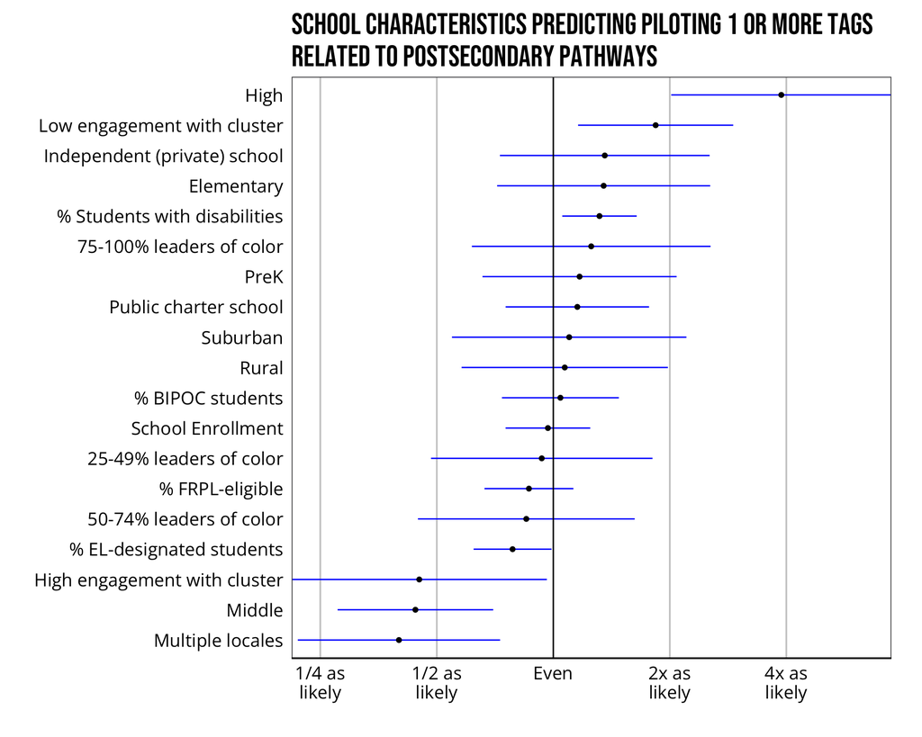

```r
dat <- mod_dat %>%
  left_join(cluster_score, by = "school_id") %>%
  filter(cluster == "Postsecondary pathways")
log_model("pilot_score", dat, "School characteristics predicting piloting 1 or more tags related to Postsecondary Pathways")
```

**Educational Justice**

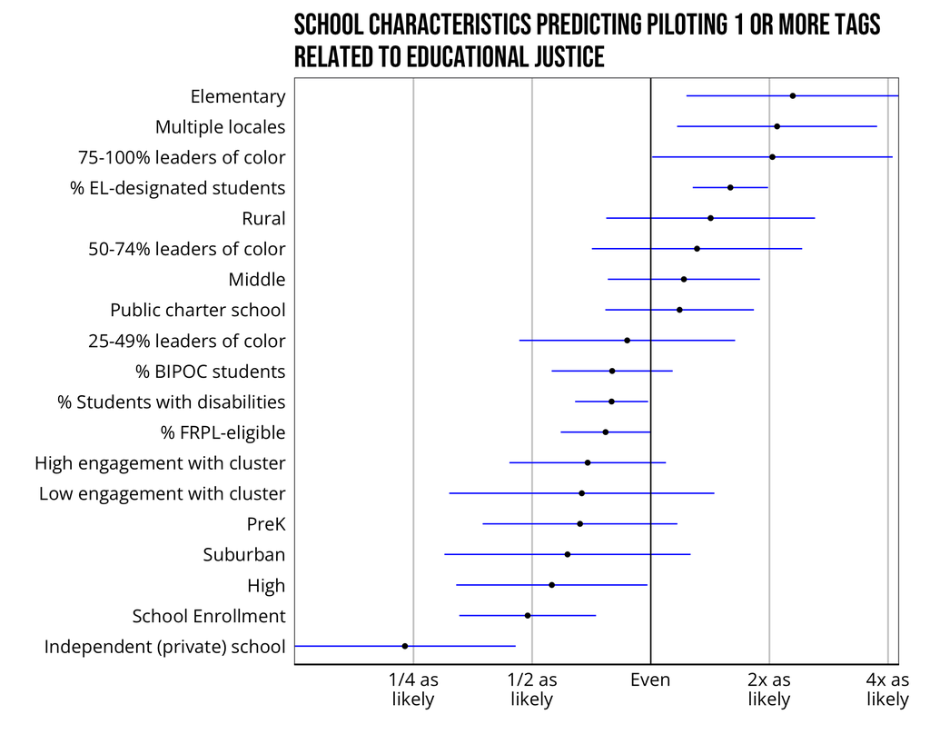

```r
dat <- mod_dat %>%
  left_join(cluster_score, by = "school_id") %>%
  filter(cluster == "Educational justice")
log_model("pilot_score", dat, "School characteristics predicting piloting 1 or more tags related to Educational Justice")
```

**Deeper Learning**

Rural schools (3x) and schools with higher-than-average BIPOC student populations (2x) were each more likely to select 1 or more tags related to Deeper Learning while schools that were already implementing many Deeper Learning tags and those with predominantly BIPOC leadership (75-100%) were about 4x less likely to select one.

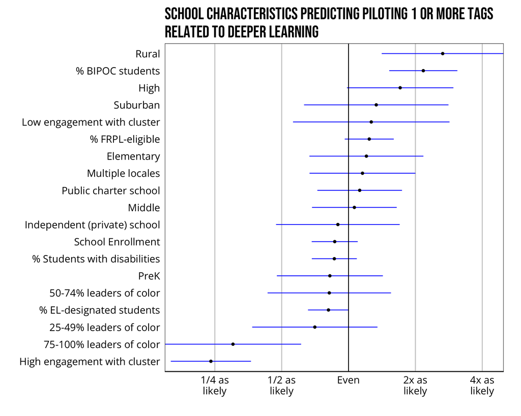

```r
dat <- mod_dat %>%
  left_join(cluster_score, by = "school_id") %>%
  filter(cluster == "Deeper learning")
log_model("pilot_score", dat, "School characteristics predicting piloting 1 or more tags related to Deeper Learning")
```

**Individualized Learning**

Schools that offer Pre-K services were 4x more likely to select 1 or more tags related to Individualized Learning while middle schools, suburban schools, and schools with 50-74% BIPOC leadership were each about 1/4x less likely to select one.

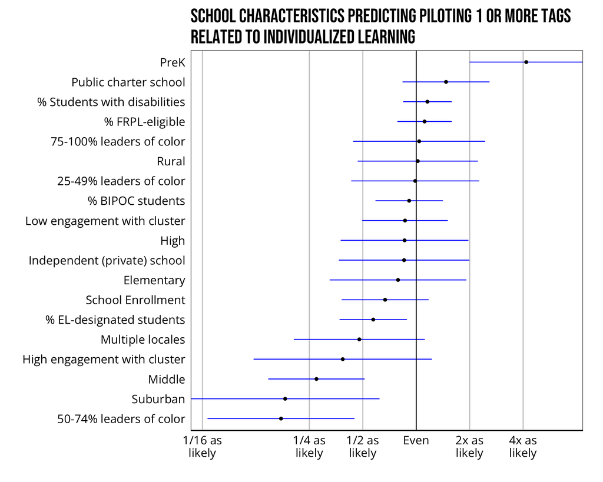

```r
dat <- mod_dat %>%
  left_join(cluster_score, by = "school_id") %>%
  filter(cluster == "Individualized learning")
log_model("pilot_score", dat, "School characteristics predicting piloting 1 or more tags related to Individualized Learning")
```